# Final Project

2025-05-04

```r
library(lubridate)
library(tidyverse)
library(caret)
library(dplyr)
library(ggthemes)
library(glmnet)
library(MASS)
library(class)
library(pROC)
library(randomForest)
library(ggplot2)
library(corrplot)
library(GGally)
library(rpart)
library(rpart.plot)
library(xgboost)
library(gbm)
library(doParallel)
library(survival)
library(survminer)
boa_data <- read.csv("data/cleaned_data/cleaned_data.csv")
boa_data$closed <- as.factor(boa_data$closed)
```

```r
boa_data <- boa_data %>%
  mutate(region_code = case_when(
    is_metropolitan == 1 ~ 3,
    is_micropolitan == 1 ~ 2,
    TRUE ~ 1
  ))
```

## I. Data Exploration

We want to take a look at the data first.

```r
glimpse(boa_data)
```

```
## Rows: 5,412
## Columns: 35
## $ X                                <int> 0, 1, 2, 3, 4, 5, 6, 7, 8, 9, 10, 11,…
## $ year                             <int> 2024, 2024, 2024, 2024, 2024, 2024, 2…
## $ FDIC_cert                        <int> 3510, 3510, 3510, 3510, 3510, 3510, 3…
## $ bank_name                        <chr> "Bank of America, National Associatio…
## $ adress                           <chr> "100 N Tryon St", "2127 E 17th St", "…
## $ branch_id                        <int> 0, 2, 3, 5, 13, 14, 17, 18, 21, 22, 2…
## $ state_abb                        <chr> "NC", "CA", "CA", "CA", "CA", "CA", "…
## $ branch_service_type              <int> 11, 11, 11, 11, 11, 11, 11, 11, 11, 1…
## $ city                             <chr> "Charlotte", "Santa Ana", "Los Alamit…
## $ county                           <chr> "Mecklenburg", "Orange", "Orange", "V…
## $ combined_stat_area               <int> 172, 348, 348, 348, 488, 488, 348, 34…
## $ combined_stat_area_name          <chr> "Charlotte-Concord, NC-SC", "Los Ange…
## $ deposits                         <int> 318260403, 223324, 371352, 232528, 25…
```

[output cut: 22 more lines]

Now, we want to see within 10 year, how many BoA branches have closed and how many are still opened.

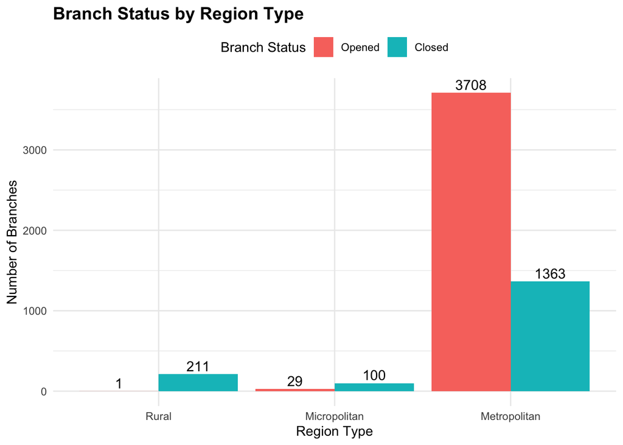

```r
boa_data %>%
  mutate(
    region = recode(factor(region_code),
                    `1` = "Rural",
                    `2` = "Micropolitan",
                    `3` = "Metropolitan"),
    branch_status = recode(factor(closed),
                           `0` = "Opened",
                           `1` = "Closed")
  ) %>%
  group_by(region, branch_status) %>%
  summarise(count = n(), .groups = "drop") %>%
  ggplot(aes(x = region, y = count, fill = branch_status)) +
  geom_bar(stat = "identity", position = position_dodge(width = 0.9)) +
  geom_text(aes(label = count),
            position = position_dodge(width = 0.9),
            vjust = -0.3, size = 4) +
  labs(
    title = "Branch Status by Region Type",
    x = "Region Type",
    y = "Number of Branches",
    fill = "Branch Status"
  ) +
  theme_minimal() +
  theme(
    legend.position = "top",
    plot.title = element_text(size = 14, face = "bold")
  )
```

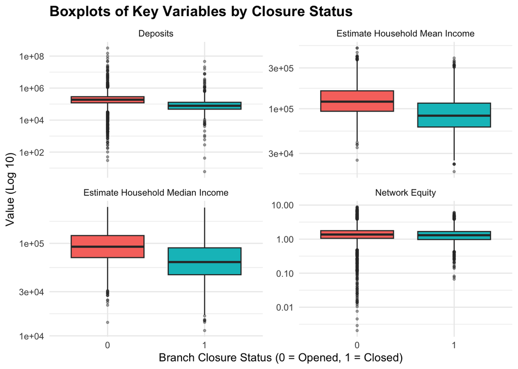

```r
boa_data %>%
  dplyr::select(closed,
         deposits,
         estimate_household_mean_income,
         estimate_household_median_income,
         network_equity) %>%
  pivot_longer(-closed, names_to = "Variable", values_to = "Value") %>%
  mutate(
    Variable = recode(Variable,
      deposits = "Deposits",
      estimate_household_mean_income = "Estimate Household Mean Income",
      estimate_household_median_income = "Estimate Household Median Income",
      network_equity = "Network Equity"
    )
  ) %>%
  ggplot(aes(x = factor(closed), y = Value, fill = factor(closed))) +
  geom_boxplot(outlier.size = 0.8, outlier.alpha = 0.4) +
  facet_wrap(~ Variable, scales = "free_y") +
  scale_y_log10() +
  labs(
    title = "Boxplots of Key Variables by Closure Status",
    x = "Branch Closure Status (0 = Opened, 1 = Closed)",
    y = "Value (Log 10)"
  ) +
  theme_minimal() +
  theme(
    legend.position = "none",
    plot.title = element_text(size = 14, face = "bold")
  )
```

## II. Statistical Analysis

```r
boa_data$deposit_change <- as.numeric(boa_data$deposit_change)
boa_data$deposit_change[boa_data$deposit_change %in% c(0, -1, Inf, -Inf)] <- NA
```

```r
df_cleaned <- boa_data %>%
  dplyr::select(closed,
                combined_stat_area,
                deposits,
                branch_share,
                market_share,
                network_equity,
                deposit_change,
                nearby_boa_branches,
                total_nearby_competitor_branches,
                total_nearby_competitor_deposits,
                total_nearby_boa_deposits,
                estimate_household_median_income,
                estimate_household_mean_income,
                region_code) %>%
  filter(if_all(everything(), ~ !is.na(.) & !is.infinite(.)))
```

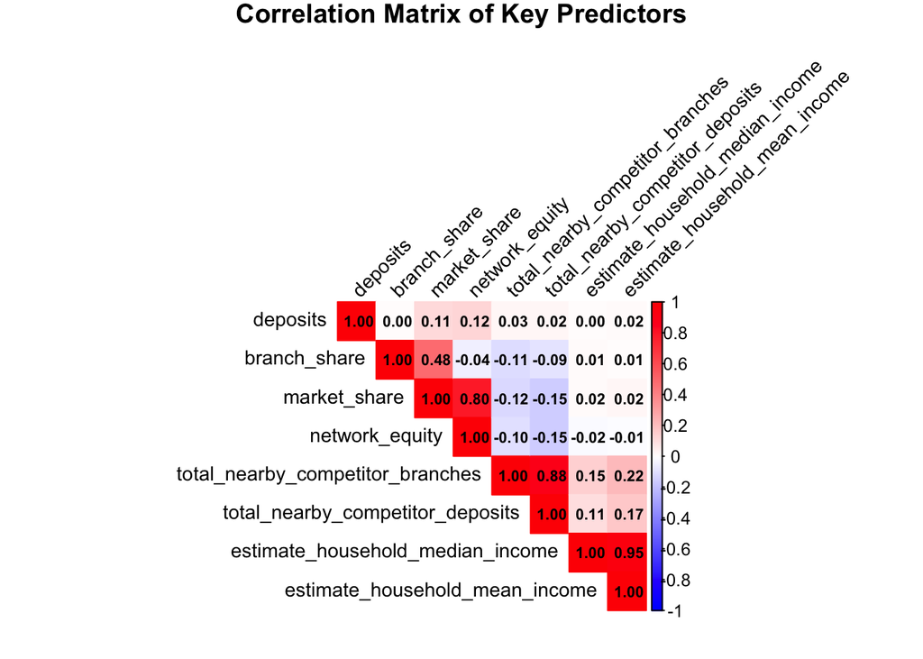

```r
# Select only numeric columns for correlation
numeric_vars <- df_cleaned %>%
  dplyr::select(deposits,
                branch_share,
                market_share,
                network_equity,
                total_nearby_competitor_branches,
                total_nearby_competitor_deposits,
                estimate_household_median_income,
                estimate_household_mean_income)

cor_matrix <- cor(numeric_vars, use = "complete.obs")

corrplot(cor_matrix,
         method = "color",
         type = "upper",
         addCoef.col = "black",
         number.cex = 0.7,
         tl.col = "black",
         tl.srt = 45,
         tl.cex = 0.9,
         col = colorRampPalette(c("blue", "white", "red"))(200),
         mar = c(0, 0, 1, 0),
         title = "Correlation Matrix of Key Predictors"
)
```

### 1. Supervised Learning

We will now split the data into training and testing data (70-30 split).

```r
set.seed(123)
train_index <- createDataPartition(df_cleaned$closed, p = 0.7, list = FALSE)
train_data <- df_cleaned[train_index, ]
test_data <- df_cleaned[-train_index, ]
```

#### 1.1. Decision Tree

We will begin by modeling a simple decision tree model.

```r
# Fit decision tree
tree_model <- rpart(closed ~ .,
                    data = train_data,
                    method = "class",
                    control = rpart.control(minsplit = 10, cp = 0.01))
```

```r
# Predict on test set
pred_class <- predict(tree_model, newdata = test_data, type = "class")

# Confusion matrix and accuracy
conf_mat <- confusionMatrix(pred_class, test_data$closed)
print(conf_mat)
```

```
## Confusion Matrix and Statistics
##
##           Reference
## Prediction    0    1
##          0 1032  127
##          1   60  273
##
##                Accuracy : 0.8747
##                  95% CI : (0.8568, 0.8911)
##     No Information Rate : 0.7319
##     P-Value [Acc > NIR] : < 2.2e-16
##
##                   Kappa : 0.6627
##
##  Mcnemar's Test P-Value : 1.39e-06
##
##             Sensitivity : 0.9451
##             Specificity : 0.6825
##          Pos Pred Value : 0.8904
##          Neg Pred Value : 0.8198
##              Prevalence : 0.7319
##          Detection Rate : 0.6917
##    Detection Prevalence : 0.7768
##       Balanced Accuracy : 0.8138
##
##        'Positive' Class : 0
##
```

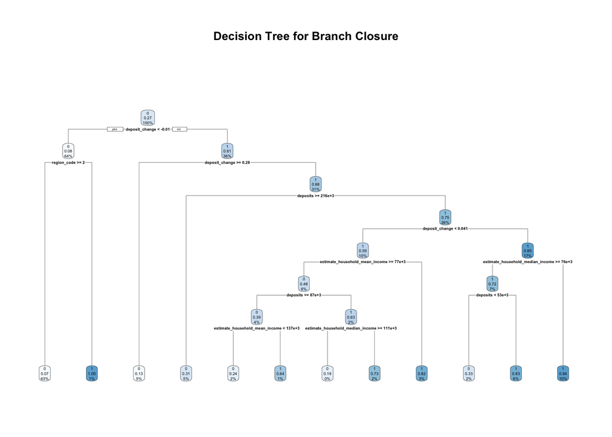

```r
# Plot the tree
rpart.plot(tree_model,
           type = 2,
           extra = 106,
           fallen.leaves = TRUE,
           box.palette = "Blues",
           main = "Decision Tree for Branch Closure")
```

We can see that most of the decisions being made in the tree are related to `deposit_change` and `deposit`. This suggests that the tree is biased towards these two features.

#### 1.2. Random Forest

To avoid the problem occured from decision tree, we will now test a more advanced model, an improved version of decision tree by adding randomness.

```r
# Train the Random Forest model
rf_model <- randomForest(closed ~ ., data = train_data, ntree = 100, importance = TRUE)

# Predict
predictions <- predict(rf_model, newdata = test_data)
```

```r
# Evaluate
confusionMatrix(predictions, test_data$closed)
```

```
## Confusion Matrix and Statistics
##
##           Reference
## Prediction    0    1
##          0 1045   91
##          1   47  309
##
##                Accuracy : 0.9075
##                  95% CI : (0.8917, 0.9217)
##     No Information Rate : 0.7319
##     P-Value [Acc > NIR] : < 2.2e-16
##
##                   Kappa : 0.7558
##
##  Mcnemar's Test P-Value : 0.0002518
##
##             Sensitivity : 0.9570
##             Specificity : 0.7725
##          Pos Pred Value : 0.9199
##          Neg Pred Value : 0.8680
##              Prevalence : 0.7319
##          Detection Rate : 0.7004
##    Detection Prevalence : 0.7614
##       Balanced Accuracy : 0.8647
##
##        'Positive' Class : 0
##
```

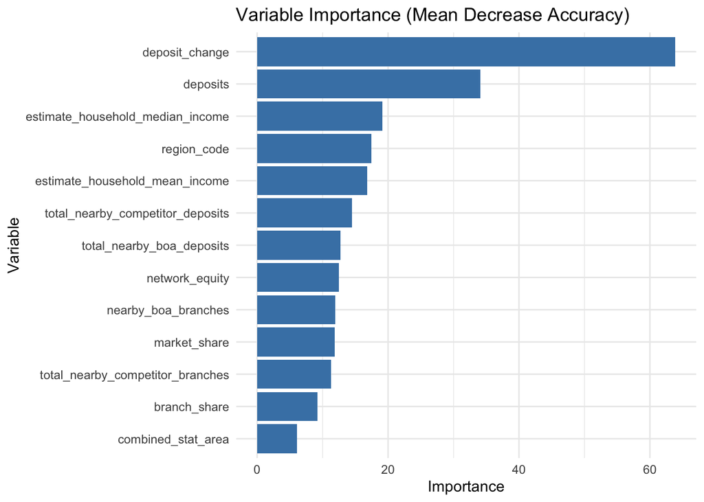

```r
# Get variable importance
importance_df <- as.data.frame(importance(rf_model))
importance_df$Variable <- rownames(importance_df)


ggplot(importance_df, aes(x = reorder(Variable, MeanDecreaseAccuracy), y = MeanDecreaseAccuracy)) +
  geom_col(fill = "steelblue") +
  coord_flip() +
  labs(title = "Variable Importance (Mean Decrease Accuracy)",
       x = "Variable",
       y = "Importance") +
  theme_minimal()
```

#### 1.3. Boosting

Lastly, we want to try boosting method. We will begin by using a basic boosting model.

```r
train_data$closed <- as.numeric(as.character(train_data$closed))

# Fit GBM model
model_boosting <- gbm(
  closed ~ .,
  data = train_data,
  distribution = "bernoulli",
  n.trees = 5000,
  shrinkage = 0.01,
  interaction.depth = 3,
  n.minobsinnode = 10,
  cv.folds = 10,
  verbose = FALSE
)
```

```r
best_iter <- gbm.perf(model_boosting, method = "cv")
```

[figure not shown]

```r
# Predict probabilities on test data
pred_probs <- predict(model_boosting, newdata = test_data, n.trees = best_iter, type = "response")

# Convert probabilities to class (e.g. 0.5 threshold)
pred_class <- ifelse(pred_probs > 0.5, 1, 0)

# Evaluate
confusionMatrix(factor(pred_class), factor(test_data$closed))
```

```
## Confusion Matrix and Statistics
##
##           Reference
## Prediction    0    1
##          0 1039   84
##          1   53  316
##
##                Accuracy : 0.9082
##                  95% CI : (0.8924, 0.9224)
##     No Information Rate : 0.7319
##     P-Value [Acc > NIR] : < 2e-16
##
##                   Kappa : 0.7601
##
##  Mcnemar's Test P-Value : 0.01038
##
##             Sensitivity : 0.9515
##             Specificity : 0.7900
##          Pos Pred Value : 0.9252
##          Neg Pred Value : 0.8564
##              Prevalence : 0.7319
##          Detection Rate : 0.6964
##    Detection Prevalence : 0.7527
##       Balanced Accuracy : 0.8707
##
##        'Positive' Class : 0
##
```

```r
# Remove target column and convert predictors to matrix
X_train <- model.matrix(closed ~ . - 1, data = train_data)
y_train <- as.numeric(as.character(train_data$closed))

X_test <- model.matrix(closed ~ . - 1, data = test_data)
y_test <- as.numeric(as.character(test_data$closed))

# Create DMatrix for XGBoost
dtrain <- xgb.DMatrix(data = X_train, label = y_train)
dtest <- xgb.DMatrix(data = X_test, label = y_test)
```

```r
hyperparam_grid <- expand.grid(
  nrounds = seq(from = 200, to = 500, by = 100),
  eta = c(0.01, 0.1),
  max_depth = c(5, 6, 7),
  gamma = c(0, 1),
  colsample_bytree = c(0.5, 0.75, 1.0),
  min_child_weight = 1,
  subsample = 1
)

num_cores <- parallel::detectCores() - 1
cl <- makeCluster(num_cores)
registerDoParallel(cl)
```

```r
tune_control <- trainControl(
  method = "cv",
  number = 10,
  verboseIter = FALSE,
  allowParallel = TRUE
)

xgb_cv <- train(
  closed ~ .,
  data = train_data,
  method = "xgbTree",
  trControl = tune_control,
  metric = "RMSE",   # maximize recall
  tuneGrid = hyperparam_grid
)

stopCluster(cl)
registerDoSEQ()
```

After tuning the model, we will use the optimal parameters to fit the final XGBoost model.

```r
final_model <- xgboost(data = as.matrix(X_train),
                       label = y_train,
                       booster = "gbtree",
                       objective = "binary:logistic",
                       nrounds = xgb_cv$bestTune$nrounds,
                       max_depth=xgb_cv$bestTune$max_depth,
                       colsample_bytree=xgb_cv$bestTune$colsample_bytree,
                       min_child_weight=xgb_cv$bestTune$min_child_weight,
                       subsample=xgb_cv$bestTune$subsample,
                       eta=xgb_cv$bestTune$eta,
                       gamma=xgb_cv$bestTune$gamma,
                       scale_pos_weight = 0.5,
                       verbose = 0)

# now evaluate
y_pred <- predict(final_model, as.matrix(X_test), type = "response")
# Convert probabilities to class (e.g. 0.5 threshold)
pred_class <- ifelse(y_pred > 0.5, 1, 0)

# Evaluate
confusionMatrix(factor(pred_class), factor(test_data$closed))
```

```
## Confusion Matrix and Statistics
##
##           Reference
## Prediction    0    1
##          0 1052   88
##          1   40  312
##
##                Accuracy : 0.9142
##                  95% CI : (0.8988, 0.9279)
##     No Information Rate : 0.7319
##     P-Value [Acc > NIR] : < 2.2e-16
##
##                   Kappa : 0.7728
##
##  Mcnemar's Test P-Value : 3.264e-05
##
##             Sensitivity : 0.9634
##             Specificity : 0.7800
##          Pos Pred Value : 0.9228
##          Neg Pred Value : 0.8864
##              Prevalence : 0.7319
##          Detection Rate : 0.7051
##    Detection Prevalence : 0.7641
##       Balanced Accuracy : 0.8717
##
##        'Positive' Class : 0
##
```

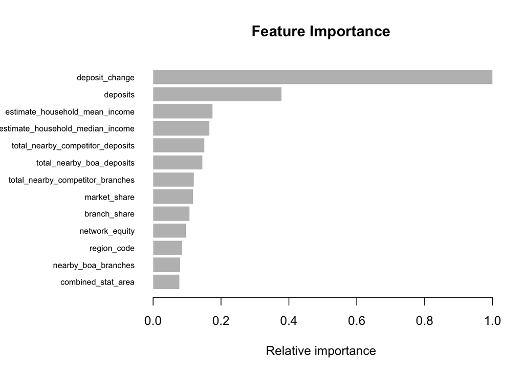

```r
importance_matrix <- xgb.importance(colnames(X_train), model = final_model)
xgb.plot.importance(importance_matrix, rel_to_first = TRUE, xlab = "Relative importance", main = "Feature Importance")
```

### 2. Survival Analysis

```r
# Step 1: Convert date
boa_data$established_date <- mdy(boa_data$established_date)

# Step 2: Extract year from date
boa_data$established_year <- year(boa_data$established_date)

# Step 3: Filter out branches just opened in 2024
boa_data <- boa_data %>% filter(established_year < 2024)

# Step 4: Calculate duration
boa_data$duration <- boa_data$year - boa_data$established_year
```

```r
df_cleaned <- boa_data %>%
  dplyr::select(closed,
                duration,
                combined_stat_area,
                deposits,
                branch_share,
                market_share,
                network_equity,
                deposit_change,
                nearby_boa_branches,
                total_nearby_competitor_branches,
                total_nearby_competitor_deposits,
                total_nearby_boa_deposits,
                estimate_household_median_income,
                estimate_household_mean_income,
                region_code
                ) %>%
  filter(if_all(everything(), ~ !is.na(.) & !is.infinite(.)))
```

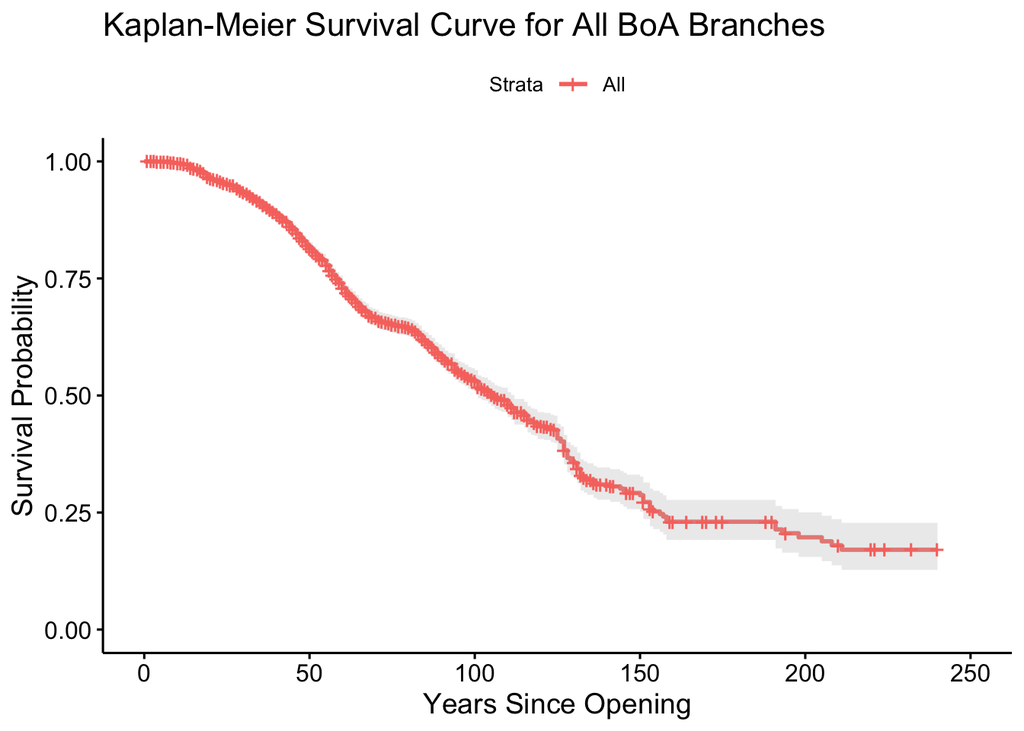

```r
df_cleaned$closed <- as.numeric(as.character(df_cleaned$closed))

surv_obj <- Surv(time = df_cleaned$duration, event = df_cleaned$closed)

km_fit <- survfit(surv_obj ~ 1, data = df_cleaned)

ggsurvplot(km_fit,
           data = df_cleaned,   # required
           conf.int = TRUE,
           risk.table = FALSE,
           title = "Kaplan-Meier Survival Curve for All BoA Branches",
           xlab = "Years Since Opening",
           ylab = "Survival Probability")
```

We divide branches based on median deposit amount to compare their survival.

```r
## Log-Rank Test: High vs Low Deposit Branches
df_cleaned <- df_cleaned %>%
  mutate(deposit_group = ifelse(deposits > median(deposits, na.rm = TRUE), "High", "Low"))

log_rank_test <- survdiff(Surv(duration, closed) ~ deposit_group, data = df_cleaned)
log_rank_test
```

```
## Call:
## survdiff(formula = Surv(duration, closed) ~ deposit_group, data = df_cleaned)
##
##                       N Observed Expected (O-E)^2/E (O-E)^2/V
## deposit_group=High 2487      264      762       325       769
## deposit_group=Low  2488     1070      572       433       769
##
##  Chisq= 769  on 1 degrees of freedom, p= <2e-16
```

- If p-value < 0.05, survival difference between high and low deposit groups is statistically significant.

Cox PH Model: Single Predictor (Deposits)

```r
cox_deposits <- coxph(Surv(duration, closed) ~ deposits, data = df_cleaned)
summary(cox_deposits)
```

```
## Call:
## coxph(formula = Surv(duration, closed) ~ deposits, data = df_cleaned)
##
##   n= 4975, number of events= 1334
##
##                coef  exp(coef)   se(coef)      z Pr(>|z|)
## deposits -9.867e-07  1.000e+00  1.591e-07 -6.203 5.54e-10 ***
## ---
## Signif. codes:  0 '***' 0.001 '**' 0.01 '*' 0.05 '.' 0.1 ' ' 1
##
##          exp(coef) exp(-coef) lower .95 upper .95
## deposits         1          1         1         1
##
## Concordance= 0.765  (se = 0.007 )
## Likelihood ratio test= 89.45  on 1 df,   p=<2e-16
## Wald test            = 38.48  on 1 df,   p=6e-10
## Score (logrank) test = 5.13  on 1 df,   p=0.02
```

Interpretation: - The hazard ratio for deposits shows the effect of deposit size on branch survival. - A value < 1 implies higher deposits reduce closure risk.

Cox PH Model: Multiple Predictors

```r
cox_full <- coxph(Surv(duration, closed) ~ deposits + deposit_change +
                    network_equity + estimate_household_median_income+ region_code,
                  data = df_cleaned)
summary(cox_full)
```

```
## Call:
## coxph(formula = Surv(duration, closed) ~ deposits + deposit_change +
##     network_equity + estimate_household_median_income + region_code,
##     data = df_cleaned)
##
##   n= 4975, number of events= 1334
##
##                                        coef  exp(coef)   se(coef)      z
## deposits                         -4.873e-07  1.000e+00  1.291e-07 -3.776
## deposit_change                    5.307e-02  1.054e+00  1.711e-02  3.101
## network_equity                   -7.292e-02  9.297e-01  3.326e-02 -2.193
## estimate_household_median_income -8.767e-06  1.000e+00  8.794e-07 -9.970
## region_code                      -4.161e-01  6.596e-01  4.560e-02 -9.125
##                                  Pr(>|z|)
## deposits                         0.000159 ***
## deposit_change                   0.001928 **
## network_equity                   0.028334 *
## estimate_household_median_income  < 2e-16 ***
## region_code                       < 2e-16 ***
## ---
## Signif. codes:  0 '***' 0.001 '**' 0.01 '*' 0.05 '.' 0.1 ' ' 1
##
##                                  exp(coef) exp(-coef) lower .95 upper .95
## deposits                            1.0000     1.0000    1.0000    1.0000
## deposit_change                      1.0545     0.9483    1.0197    1.0905
## network_equity                      0.9297     1.0756    0.8710    0.9923
## estimate_household_median_income    1.0000     1.0000    1.0000    1.0000
## region_code                         0.6596     1.5160    0.6032    0.7213
##
## Concordance= 0.665  (se = 0.009 )
## Likelihood ratio test= 361.5  on 5 df,   p=<2e-16
## Wald test            = 351.8  on 5 df,   p=<2e-16
## Score (logrank) test = 384.4  on 5 df,   p=<2e-16
```

Plot Predicted Survival for Average Branch in Different Regions

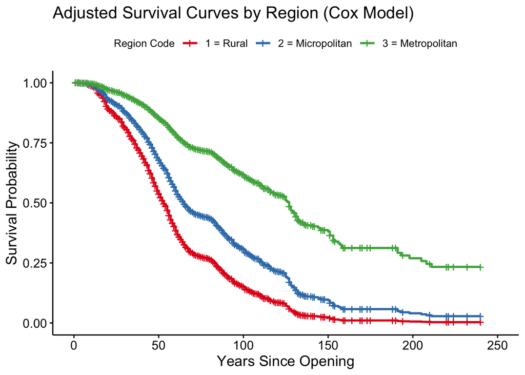

```r
df_cleaned$region_code <- as.numeric(as.character(df_cleaned$region_code))
# Build newdata for each region (1, 2, 3)
newdata <- df_cleaned %>%
  group_by(region_code) %>%
  summarise(
    deposits = mean(deposits, na.rm = TRUE),
    deposit_change = mean(deposit_change, na.rm = TRUE),
    network_equity = mean(network_equity, na.rm = TRUE),
    estimate_household_median_income = mean(estimate_household_median_income, na.rm = TRUE),
    .groups = "drop"
  )

# Fit and plot survival curves
fit_region <- survfit(cox_full, newdata = newdata)

ggsurvplot(fit_region,
           data = df_cleaned,
           conf.int = FALSE,
           risk.table = FALSE,
           legend.title = "Region Code",
           legend.labs = c("1 = Rural", "2 = Micropolitan", "3 = Metropolitan"),
           title = "Adjusted Survival Curves by Region (Cox Model)",
           xlab = "Years Since Opening",
           ylab = "Survival Probability",
           palette = "Set1")
```

Metropolitan branches may show higher survival